# White Wine Data

# Analysis

## What is the structure of your dataset?

There are 4898 observations in the dataset. Qualities range from integer values 3-9, and are normally distributed. Other observiations: Median Alcohol content is 10.40 Median quality in 6. Most wines in the dataset are dry, with the median residual sugar value being 5.2

## What is/are the main feature(s) of intrest in your dataset?

The main feature of intrest to me is the quality score, I want to see if we can estimate the quality of wine based on its properties.

## What are the features in the dataset do you think will support your investigation into your feature(s) of intreast?

I think some of the features of intrest which may affect the quality of wine are volatile.acidity (high levels can make wine taste like vinegar), free.sulfur.dioxide (high levels can be detected by taste/nose) and the ratio of acid to sweet (See below)

## Did you create any new variables from existing variables in your dataset?

In_wine_tasting, an important factor in the quality of wine is the balance of acidity vs. sweetness. So I also calculated a sweet to acid ratio.

```
##    Min. 1st Qu.  Median    Mean 3rd Qu.    Max.
## -2.0159 -0.2992  0.2803  0.4769  1.4036  2.7014
```

I also added the bound level of sulphates

## Of the features you investigated were there any unusual distributions? Did you perform any operations on the data to tidy, adjust, or change the form of the data? If so why?

I found this artical so decided to group the wine as specified by the sweetness levels dictated by the EU [linked phrase](http://en.wikipedia.org/wiki/Sweetness_of_wine#Residual_sugar)

### Add groupings according to wine research.

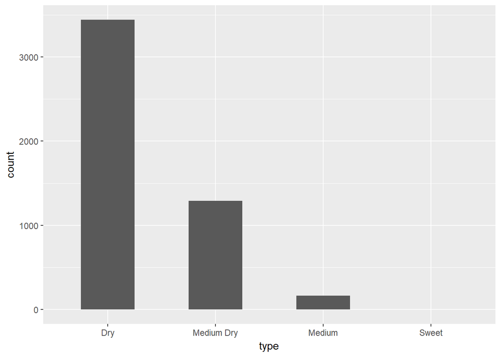

```
##        Dry Medium Dry     Medium      Sweet
##       3442       1290        165          1
```

Judging by the sample it looks like this variety of grape is used to produce mainly dry, or medium dry wines. There are only a small proportion of medium and sweet wines in the sample.

==================================================================================================

# BIVARIATE SECTION:

# Bivariate Plot:

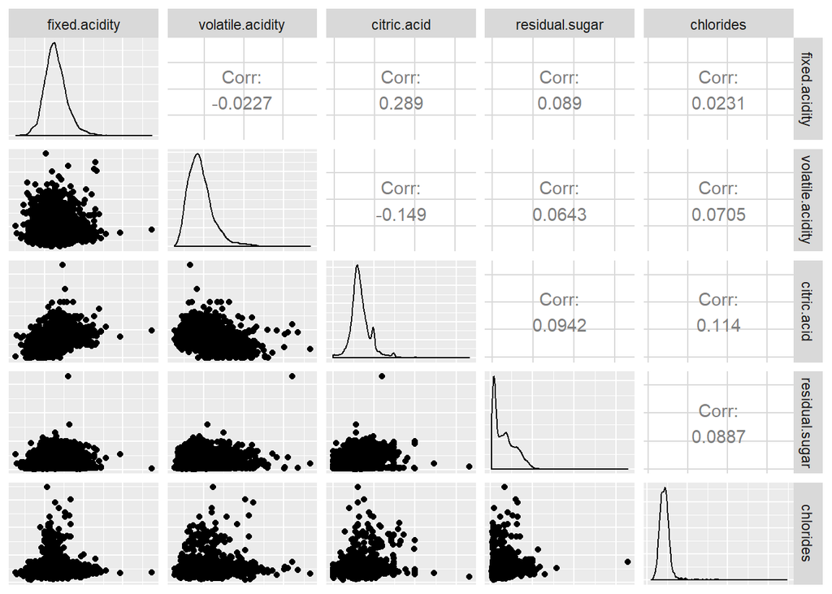

There are some obvious correlations that I dont find very intresting such as, level of citric acid and fixed acidity, level of free sulphur dioxide and bound sulphur dioxide, level of fixed acidity and ph.

Quality seems to be affected to some extent in decreasing levels of influence by alcohol level (0.436 correlation), density (-0.307), chlorides(-0.21), bound.sulphur.dioxide (-0.21) and volatile acidity(-0.195), i would like to examine these more.

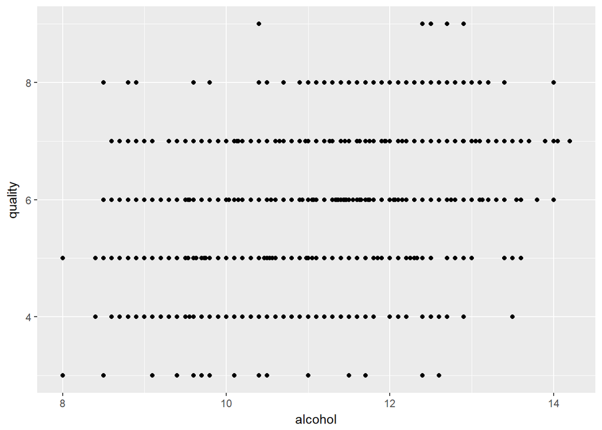

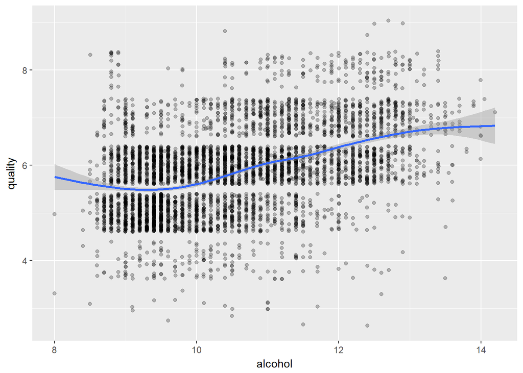

There appears to be a generally increase in quality of wine as alcohol level increases, as shown by the positive correlation (0.436). There appears more variance at higher and lower concentrations. There are strips in the scoring which are because of the integer quality scores.

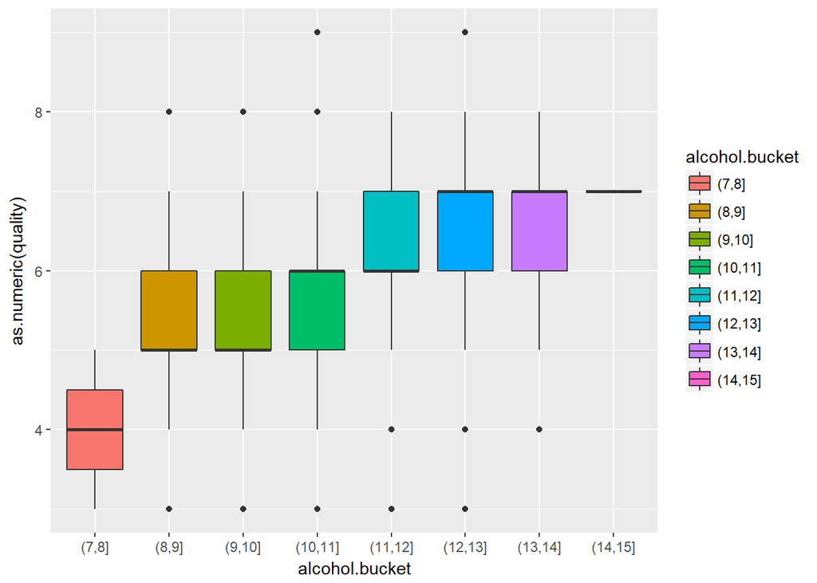

```
##    Min. 1st Qu.  Median    Mean 3rd Qu.    Max.
##    8.00    9.50   10.40   10.51   11.40   14.20
```

```
##   (7,8]   (8,9]  (9,10] (10,11] (11,12] (12,13] (13,14] (14,15]
##       2     500    1583    1252     850     609     100       2
```

```
## # A tibble: 8 x 6
##   alcohol.bucket lower median upper     mean     n
##           <fctr> <dbl>  <dbl> <dbl>    <dbl> <int>
## 1          (7,8]   3.5      4   4.5 4.000000     2
## 2          (8,9]   5.0      5   6.0 5.606000   500
## 3         (9,10]   5.0      5   6.0 5.487682  1583
## 4        (10,11]   5.0      6   6.0 5.864217  1252
## 5        (11,12]   6.0      6   7.0 6.190588   850
## 6        (12,13]   6.0      7   7.0 6.571429   609
## 7        (13,14]   6.0      7   7.0 6.720000   100
## 8        (14,15]   7.0      7   7.0 7.000000     2
```

Here I have split the alcohol levels into buckets, so that we can look at the data in a slightly different way. You see a very evidentially rise in the median quality scores as alcohol level increases.

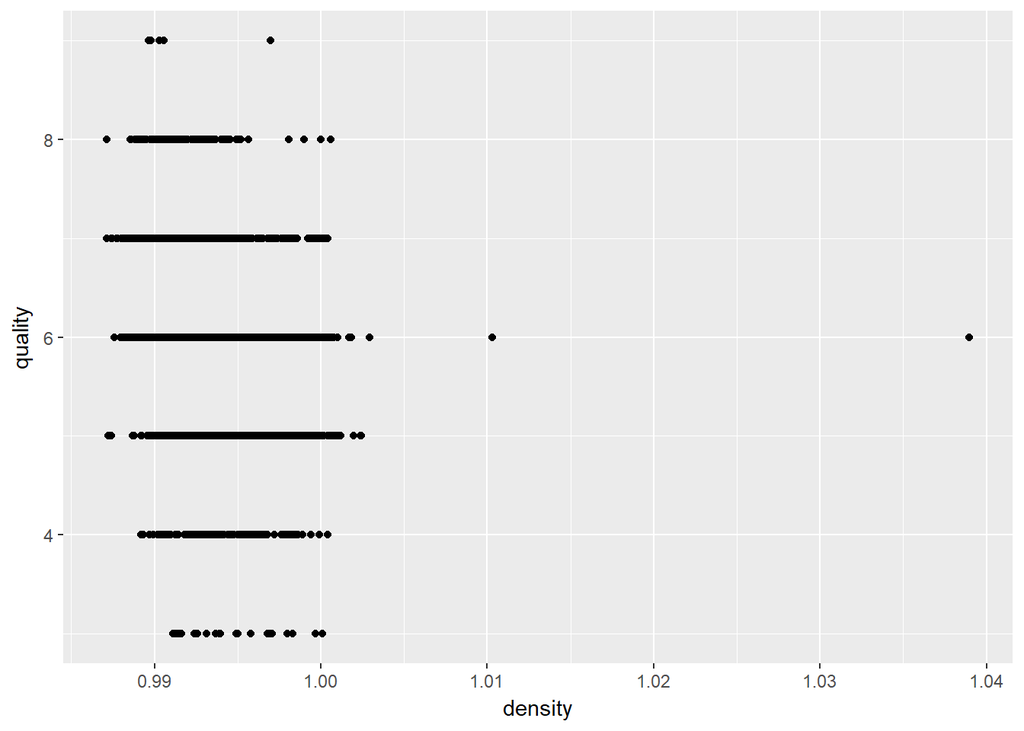

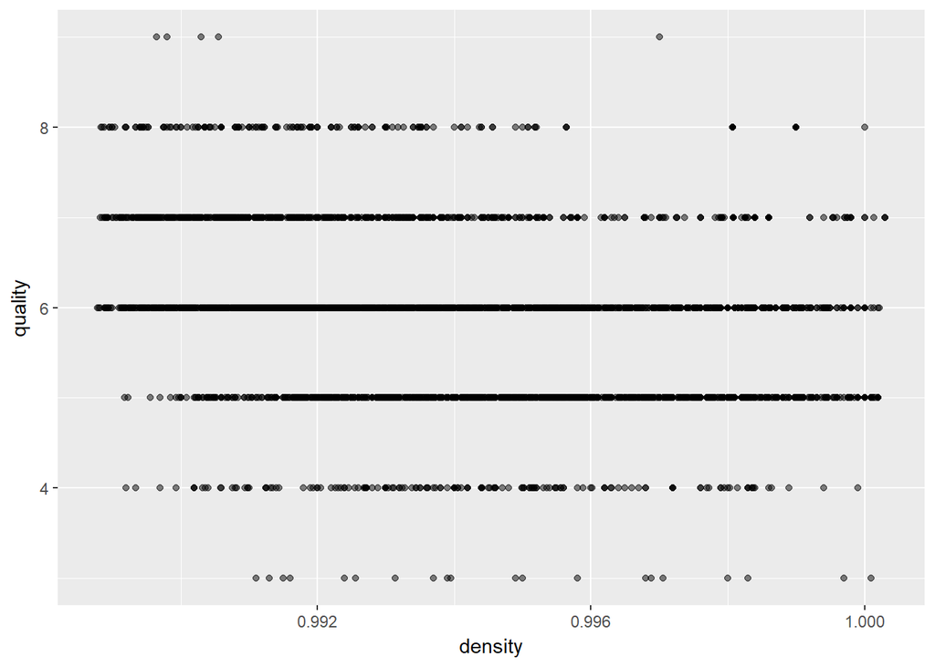

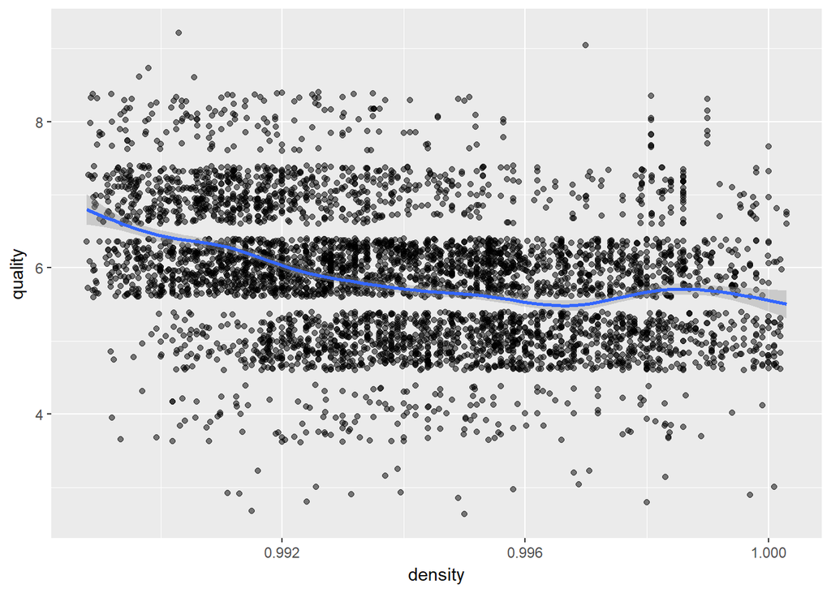

Here is a plot removing the outliers (lower and upper 1%) and plotting a trend line. This shows the slight negative correlation between density and quality (-0.307).

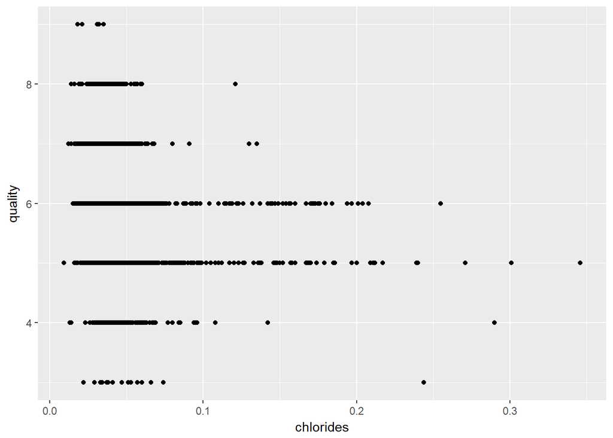

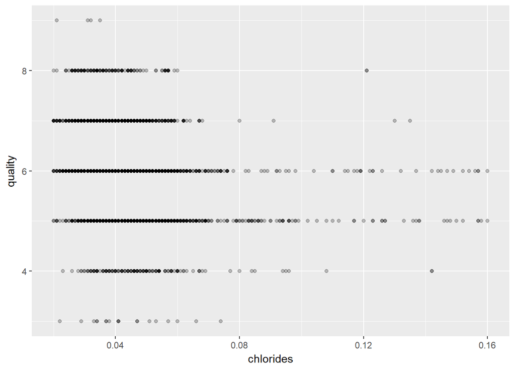

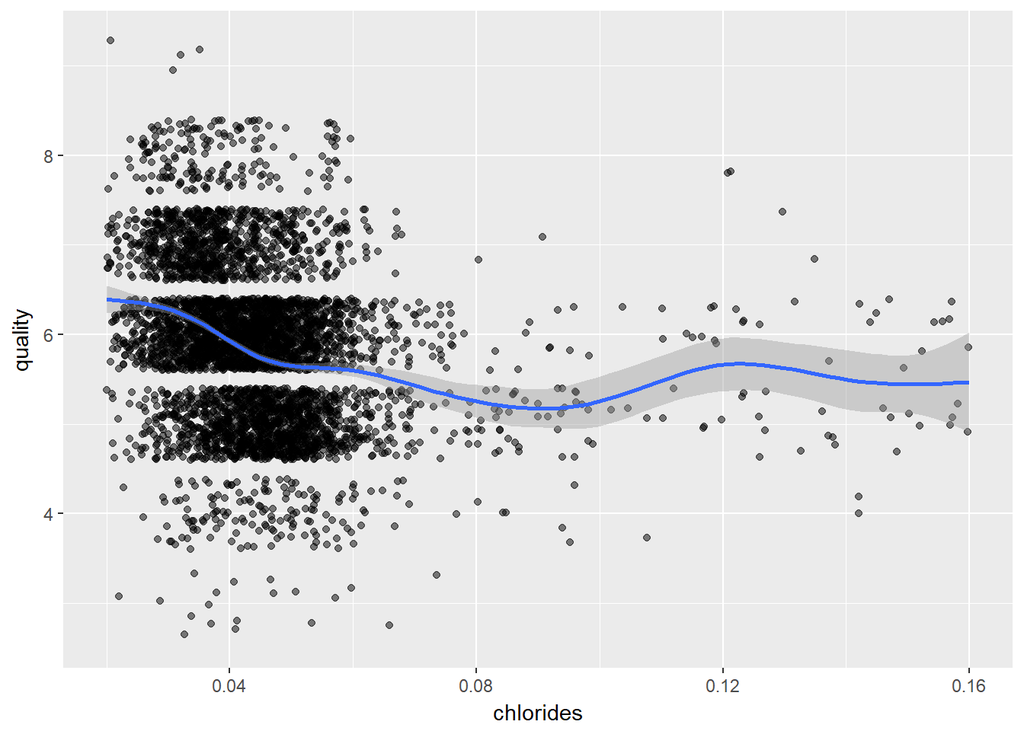

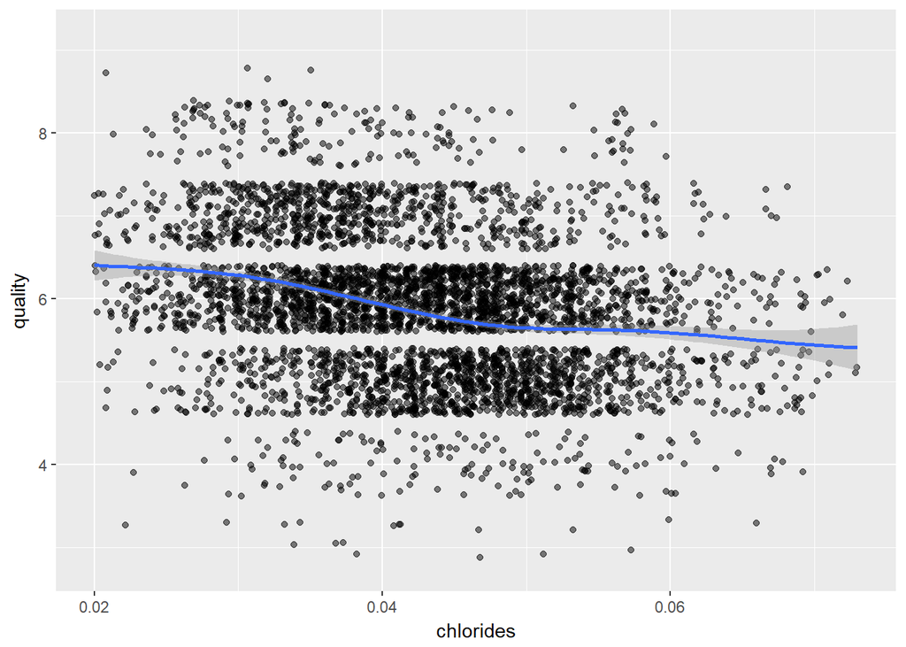

```
##    Min. 1st Qu.  Median    Mean 3rd Qu.    Max.
## 0.00900 0.03600 0.04300 0.04577 0.05000 0.34600
```

Most wines have chloride levels between 0.01 and 0.045. There are a several outliers with varing qualities of wine. In my later plots I removed the bottom 1% and top 4% from my plot. This shows that there is a small negative correlation between chlorides and quality (-0.21).

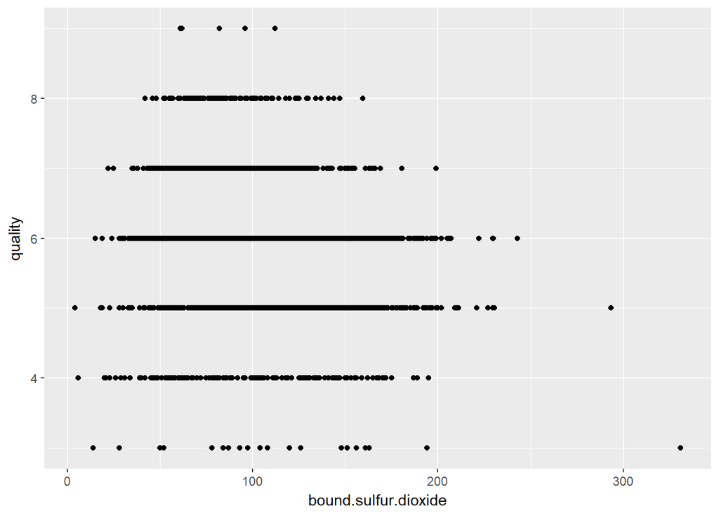